# Plotting Assignment #3

- Show All Code
- Hide All Code
- View Source

Summaries, Facets, and Themes

Author

Haley Brumberger

Published

February 26, 2026

# 1 Setup

Using R version 4.5.2 (2025-10-31) , R Core Team (2022), and ggplot2 version 4.0.0 from the tidyverse (Wickham et al. 2019).

```r
# load packages
library(ggplot2)
library(dplyr)
```

# 2 Data

```r
# load data

beers <- readxl::read_excel("data/beers.xlsx")
breweries <- readxl::read_excel("data/breweries.xlsx")
```

# 3 Plots

## 3.1 Making a plot theme to save time

```r
# Making a theme
my_plot_theme <-
  theme_bw() +
  theme(
    plot.title = element_text(size = 11, face = "bold", hjust = 0.5), #enlarging, bolding, centering the title
    panel.grid.major.y = element_line(color = "black", linewidth = 0.1), #making the y major tick marks bolder than the minor tick marks (also below)
    panel.grid.minor.y = element_line(color = "black", linewidth = 0.05),
    panel.grid.major.x = element_blank(), #getting rid of x axis lines because the vertical lines are distracting and unnecessary in a box plot (also below)
    panel.grid.minor.x = element_blank(),
    axis.title = element_text(size = 10), #setting axis title size
    axis.text.x = element_text(size = 7, angle = 90, vjust = 0.5, hjust = 1), #setting axis text size, angle, justification
    legend.title = element_text(size = 11, hjust = 0.5), #setting legend title size
    legend.text = element_text(size = 11), #setting legend text size
    legend.margin = margin(t = 2, r = 2, b = 2, l = 2, unit = "pt"), #making the margins of the legend box smaller so it doesn't take up as much room in the plot
    legend.key.height = unit(0.4, "lines"), #setting the height of the legend key line
    legend.key.width = unit(1, "lines"), #setting the width of the legend key line
    legend.position = "inside", #moving the legend to inside of the plot
    legend.position.inside = c(0.99, 0.98), #setting the legend position in reference to the line below
    legend.justification = c("right", "top"), #reference frame for setting the legend position
    legend.box.background = element_rect(
      #setting the legend to have a white background and a black outline,
      color = "black",
      fill = "white",
      linewidth = 0.25
    )
  )
```

## 3.2 Plot 1: Craft Breweries in Each State

Figure 1 displays, via column chart, the number of craft breweries in each state in decreasing order. Colorado has the most breweries by 8; CO has 47, while the next state, with the second-most breweries (California), has 39. My interpretation is that Colorado’s brewery/brewing culture is somehow conducive to variety, such that people come to Colorado to start breweries (like Senator John Hickenlooper!). Also, I think that many people find that the outdoorsy lifestyle of Colorado lends itself to beer-drinking, as well, so there is a market/clientele for all the different breweries to stay open! It is noteworthy that most states have below the average number of breweries, which is approximately 11, so the higher-brewery states are clearly skewing the mean higher.

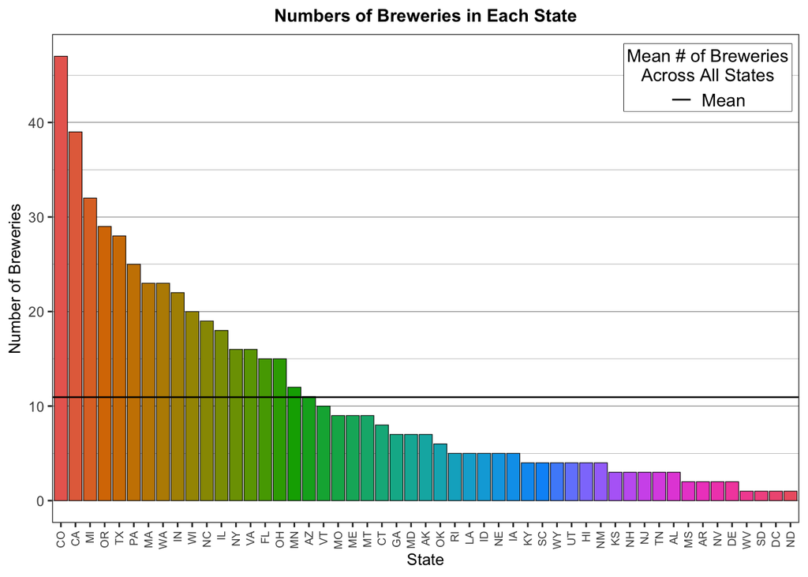

Figure 1: Craft breweries in each state, with a black line showing the mean number of breweries across all state.

```r
breweries_by_state <- breweries |> #make a new data frame with breweries grouped by state and adding a column "n" that has the number of breweries/entries per grouped state
  summarize(n = n(), .by = state) |>
  arrange(desc(n)) |>
  mutate(state = factor(state, levels = state)) # # convert state to factor with levels in the order of arranged data so that ggplot plots them in descending order, order states by number of breweries


breweries_by_state |>
  ggplot() +
  aes(x = state, y = n, fill = state) +
  geom_col(color = "black", linewidth = 0.2) + #giving the columns a skinny (0.2) black outline
  geom_hline(
    mapping = aes(yintercept = mean(n), color = "Mean")
  ) + #calculating the mean # of breweries and adding a horizontal line across with that value, and setting the color to "Mean" for "Mean" show up in the legend
  scale_color_manual(
    name = "Mean # of Breweries\nAcross All States", #setting legend title for the color entry
    values = c("Mean" = "black") #setting the color of "Mean" to black
  ) +
  labs(
    # setting x and y axis labels and the title
    x = "State",
    y = "Number of Breweries",
    title = "Numbers of Breweries in Each State"
  ) +
  scale_fill_hue(c = 100, l = 60) + #setting the colors of the bars--this maps each level to an evenly spaced hue on the color wheel, where c is chroma (intensity of color between 0-360) and l is luminence (lightness between 0-100)
  guides(fill = "none") + #getting rid of the legend since the fill just serves as a visual way to separate each state
  my_plot_theme
```